## Report: act_report

# We rate dogs - a data exploration

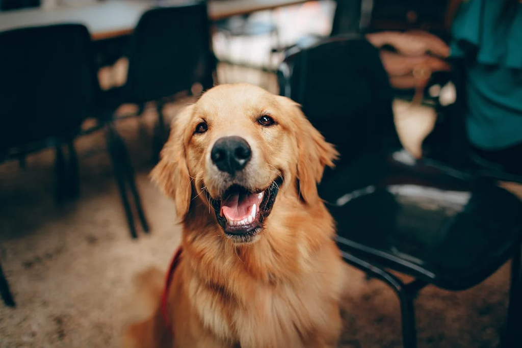

We rate dogs is a twitter account that rates peoples dogs. It also provides humorous comments based on the picture of the dog provided. The account has received a lot of attention including media attention and was started in 2015 by Matt Nelson who was a college student at the time

We applied data analysis techniques on we rate dogs in order to drive insights from the twitter page. Our analysis was driven by firstly grouping the breeds of dogs and looking to insight on each breed of the dog.

We were able to find some interesting insights which we think that the reader could find some value in

## Which dogs do users submit the most

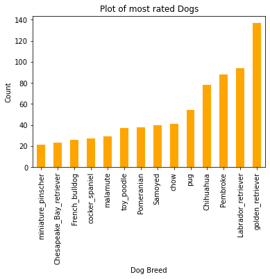

So which dogs do followers submit the most to the we rate dogs, or put differently which dogs are popular amongst followers of the we rate dogs twitter page. Golden retrievers were the most submitted dogs to the we rate dogs platform, followed by Labrador retrievers , Pembrooke’s and then Chihuahua’s

## Which dogs got the most retweets

The crown for retweets went to the French Bulldog with the highest average retweets, followed by Samoyeds and Labrador retrievers. The French Bulldog was the undisputed king with about 4684 average retweets while the Samoyed got 4623 average retweets and the Labroder retriever coming at third with 3951 average retweets.

## Which dogs got favourited the most

The French bulldog one this round with 17,913 average favourites , with the Samoyed coming second with 13574 average favourites and the Golden Retriever coming third with 12477 average favourites.